# Cognition - Immediate recall

# 1 Description of DataSchema variable

The description of harmonised variable is the following:

- Short name: `cog_imm`
- Variable label: `Cognition - immediate recall`
- Variable description: `Immediate recall of common nouns from a list. Variable dichotomised by first quartil with value 0 and higher with value 1.`
- Domain: `Health status and functional limitations`
- Value type: `categorical`
- Category coding:

| **Code** | **Category Label** |
| --- | --- |
| 0 | <=25% |
| 1 | >25% |

- Category missings:

| **Code** | **Category Label** |
| --- | --- |
| 991 | CAPI/interviewer error |
| 992 | Impute |
| 993 | Disable to measure |
| 994 | Not attempt/not done |
| 995 | Does not answer |
| 996 | Not applicable |
| 997 | Refuse |
| 998 | Do not know |
| 999 | Missing |

- Short name: `cog_imm_c`
- Variable label: `Cognition - immediate recall. Continuous variable.`
- Variable description: `Immediate recall of common nouns from a list. The total number of words correctly immediately recalled during a test of verbal memory.`
- Domain: `Health status and functional limitations`
- Value type: `continuous`
- Category missings:

| **Code** | **Category Label** |
| --- | --- |
| 991 | CAPI/interviewer error |
| 992 | Impute |
| 993 | Disable to measure |
| 994 | Not attempt/not done |
| 995 | Does not answer |
| 996 | Not applicable |
| 997 | Refuse |
| 998 | Do not know |
| 999 | Missing |

# 2 Data process

## 2.1 England

### 2.1.1 Wave 1

#### 2.1.1.1 Study-specific variable description

| **Name** | `cflisen` |
| --- | --- |
| **Label** | `Now please tell me the words that you can recall. Enter number of words recalled` |
| **Table name** | `wave_1_core_data_v3` |
| **Categories** | `Continuous Variable 0-10` |
| **Missings** | `-9 = Refusal` `-8 = Don't know` `-1 = Not applicable` |
| **Description** |  |

Immediate recall continuous

| Sample size | Missing values |
| --- | --- |
| 12099 | 384 |

Values

|  | No-missings | -9 | -8 | -1 | NA |
| --- | --- | --- | --- | --- | --- |
| Frequency | 11715.00 | 76.00 | 17.00 | 291.00 | 0 |
| Percentage | 96.83 | 0.63 | 0.14 | 2.41 | 0 |

Summary

| Min. | 1st Qu. | Median | Mean | 3rd Qu. | Max. |
| --- | --- | --- | --- | --- | --- |
| 0 | 4 | 6 | 5.46 | 7 | 10 |

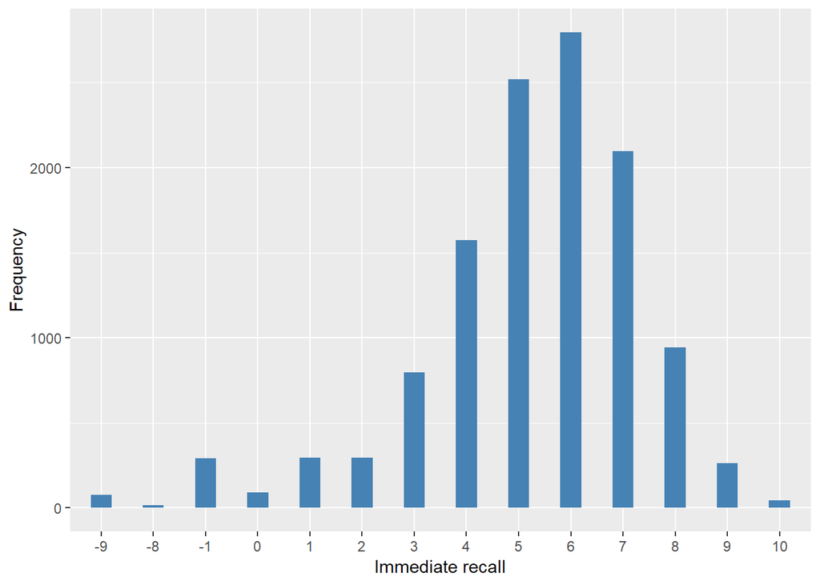

#### 2.1.1.2 Harmonisation algorithm

To compute the harmonize variable `cog_imm_c` from the study-specific variable the missing values have to be recoded as follows:

- `-9 Refusal into 997`
- `-8 Don't know into 998`
- `-1 Not applicable into 996`
- `NA into 999`

To compute the harmonized variable `cog_imm` from `cog_imm_c` it has to be recoded as follows:

- `cog_imm_c <=25% into 0`
- `cog_imm_c >25% into 1`

**R script**

```r
## cog_imm_c
ELSA_ds_w1 <- tibble(id = ELSA_w1_cog_imm$id)
ELSA_ds_w1$cog_imm_c <- car::recode(ELSA_w1_cog_imm$cflisen, "-9 = 997; -8 = 998; -1 = 996")


## cog_imm
Q <- quantile(car::recode(ELSA_ds_w1$cog_imm_c, "999=NA;997=NA;998=NA;996=NA"),
    probs = 1/4, na.rm = TRUE, names = FALSE)

ELSA_ds_w1$cog_imm <- car::recode(ELSA_ds_w1[[2]], "0:Q=0; (Q+1):10=1")
```

#### 2.1.1.3 Statistical description of the new harmonised variable

Immediate recall of common nouns from a list. The total number of words correctly immediately recalled during a test of verbal memory

| Sample size | Missing values |
| --- | --- |
| 12099 | 384 |

Values

|  | No-missings | 991 | 992 | 993 | 994 | 995 | 996 | 997 | 998 | 999 | NA |
| --- | --- | --- | --- | --- | --- | --- | --- | --- | --- | --- | --- |
| Frequency | 11715.00 | 0 | 0 | 0 | 0 | 0 | 291.00 | 76.00 | 17.00 | 0 | 0 |
| Percentage | 96.83 | 0 | 0 | 0 | 0 | 0 | 2.41 | 0.63 | 0.14 | 0 | 0 |

Summary

| Min. | 1st Qu. | Median | Mean | 3rd Qu. | Max. |
| --- | --- | --- | --- | --- | --- |
| 0 | 4 | 6 | 5.46 | 7 | 10 |

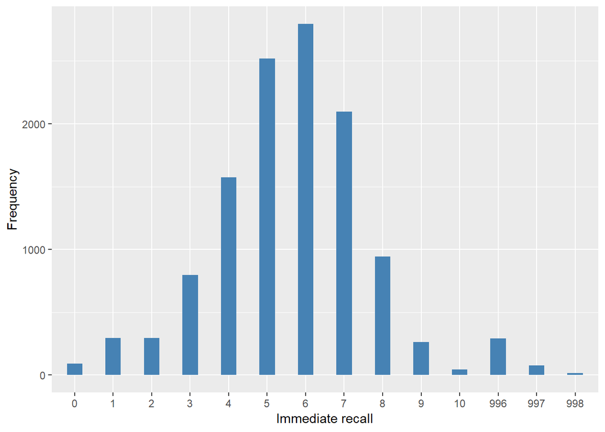

Immediate recall of common nouns from a list. Variable dichotomised by first quartil with value 0 and higher with value 1

| Sample size | Missing values |
| --- | --- |
| 12099 | 384 |

Category

|  | 0 | 1 |
| --- | --- | --- |
| Frequency | 3055.00 | 8660.00 |
| Percentage | 25.25 | 71.58 |

Type of missing

|  | 991 | 992 | 993 | 994 | 995 | 996 | 997 | 998 | 999 | NA |
| --- | --- | --- | --- | --- | --- | --- | --- | --- | --- | --- |
| Frequency | 0 | 0 | 0 | 0 | 0 | 291.00 | 76.00 | 17.00 | 0 | 0 |
| Percentage | 0 | 0 | 0 | 0 | 0 | 2.41 | 0.63 | 0.14 | 0 | 0 |

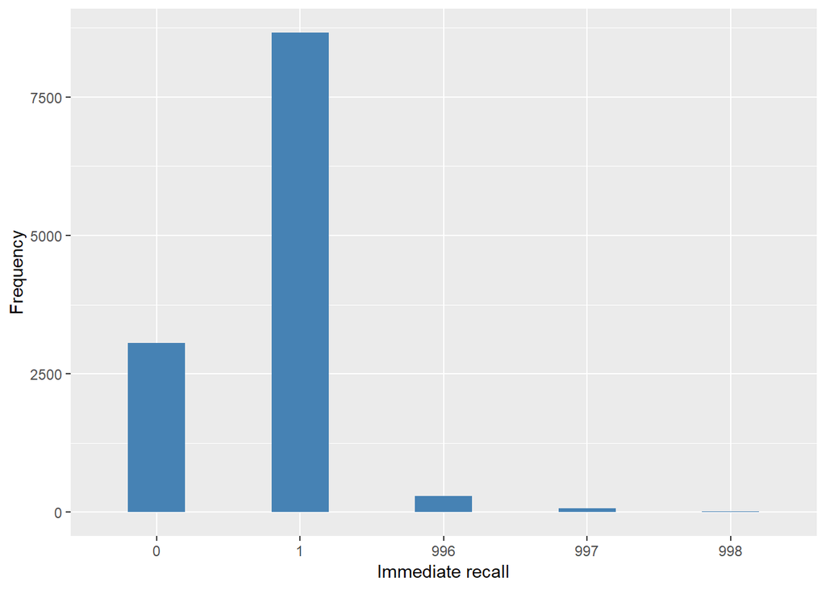

#### 2.1.1.4 Validation

Continuous vs Dichotomous

|  | 0:4->0 | 5:10->1 | -1->996 | -9->997 | -8->998 |
| --- | --- | --- | --- | --- | --- |
| continuous | 3055 | 8660 | 291 | 76 | 17 |
| dichotomous | 3055 | 8660 | 291 | 76 | 17 |

### 2.1.2 Wave 2

#### 2.1.2.1 Study-specific variable description

| **Name** | `CfLisEn` |
| --- | --- |
| **Label** | `Number of words recalled immediately` |
| **Table name** | `wave_2_core_data_v4` |
| **Categories** | `Continuous Variable 0-10` |
| **Missings** | `-9 = Refusal` `-8 = Don't know` `-1 = Not applicable` |
| **Description** |  |

Immediate recall continuous

| Sample size | Missing values |
| --- | --- |
| 9432 | 193 |

Values

|  | No-missings | -9 | -8 | -1 | NA |
| --- | --- | --- | --- | --- | --- |
| Frequency | 9239.00 | 32.00 | 13.00 | 148.00 | 0 |
| Percentage | 97.95 | 0.34 | 0.14 | 1.57 | 0 |

Summary

| Min. | 1st Qu. | Median | Mean | 3rd Qu. | Max. |
| --- | --- | --- | --- | --- | --- |
| 0 | 5 | 6 | 5.658 | 7 | 10 |

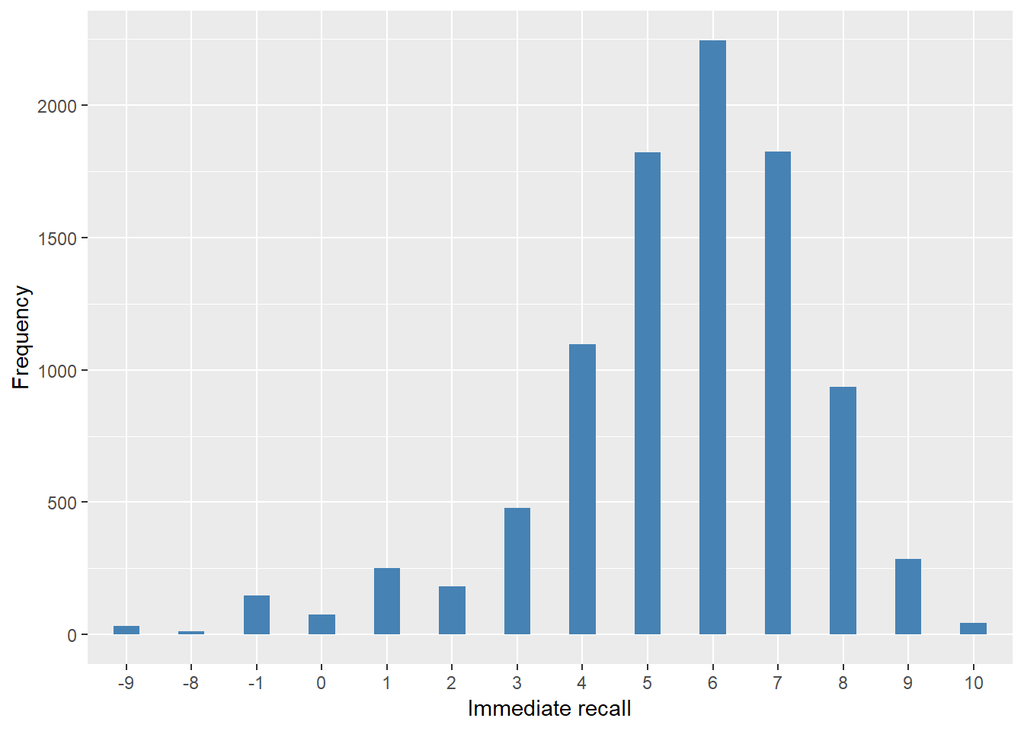

#### 2.1.2.2 Harmonisation algorithm

To compute the harmonize variable `cog_imm_c` from the study-specific variable the missing values have to be recoded as follows:

- `-9 Refusal into 997`
- `-8 Don't know into 998`
- `-1 Not applicable into 996`
- `NA into 999`

To compute the harmonized variable `cog_imm` from `cog_imm_c` it has to be recoded as follows:

- `cog_imm_c <=25% into 0`
- `cog_imm_c >25% into 1`

**R script**

```r
## cog_imm_c
ELSA_ds_w2 <- tibble(id = ELSA_w2_cog_imm$id)
ELSA_ds_w2$cog_imm_c <- car::recode(ELSA_w2_cog_imm$CfLisEn, "-9 = 997; -8 = 998; -1 = 996")


## cog_imm
Q <- quantile(car::recode(ELSA_ds_w2$cog_imm_c, "999=NA;997=NA;998=NA;996=NA"),
    probs = 1/4, na.rm = TRUE, names = FALSE)

ELSA_ds_w2$cog_imm <- car::recode(ELSA_ds_w2[[2]], "0:Q=0; (Q+1):10=1")
```

#### 2.1.2.3 Statistical description of the new harmonised variable

Immediate recall of common nouns from a list. The total number of words correctly immediately recalled during a test of verbal memory

| Sample size | Missing values |
| --- | --- |
| 9432 | 193 |

Values

|  | No-missings | 991 | 992 | 993 | 994 | 995 | 996 | 997 | 998 | 999 | NA |
| --- | --- | --- | --- | --- | --- | --- | --- | --- | --- | --- | --- |
| Frequency | 9239.00 | 0 | 0 | 0 | 0 | 0 | 148.00 | 32.00 | 13.00 | 0 | 0 |
| Percentage | 97.95 | 0 | 0 | 0 | 0 | 0 | 1.57 | 0.34 | 0.14 | 0 | 0 |

Summary

| Min. | 1st Qu. | Median | Mean | 3rd Qu. | Max. |
| --- | --- | --- | --- | --- | --- |
| 0 | 5 | 6 | 5.658 | 7 | 10 |

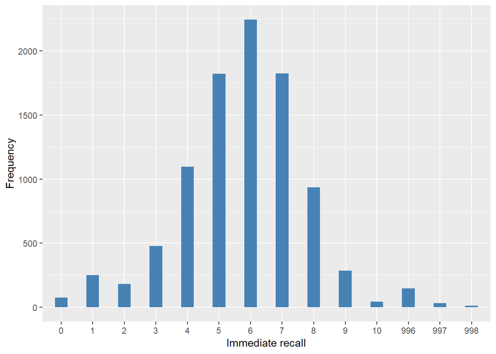

Immediate recall of common nouns from a list. Variable dichotomised by first quartil with value 0 and higher with value 1

| Sample size | Missing values |
| --- | --- |
| 9432 | 193 |

Category

|  | 0 | 1 |
| --- | --- | --- |
| Frequency | 3905.0 | 5334.00 |
| Percentage | 41.4 | 56.55 |

Type of missing

|  | 991 | 992 | 993 | 994 | 995 | 996 | 997 | 998 | 999 | NA |
| --- | --- | --- | --- | --- | --- | --- | --- | --- | --- | --- |
| Frequency | 0 | 0 | 0 | 0 | 0 | 148.00 | 32.00 | 13.00 | 0 | 0 |
| Percentage | 0 | 0 | 0 | 0 | 0 | 1.57 | 0.34 | 0.14 | 0 | 0 |

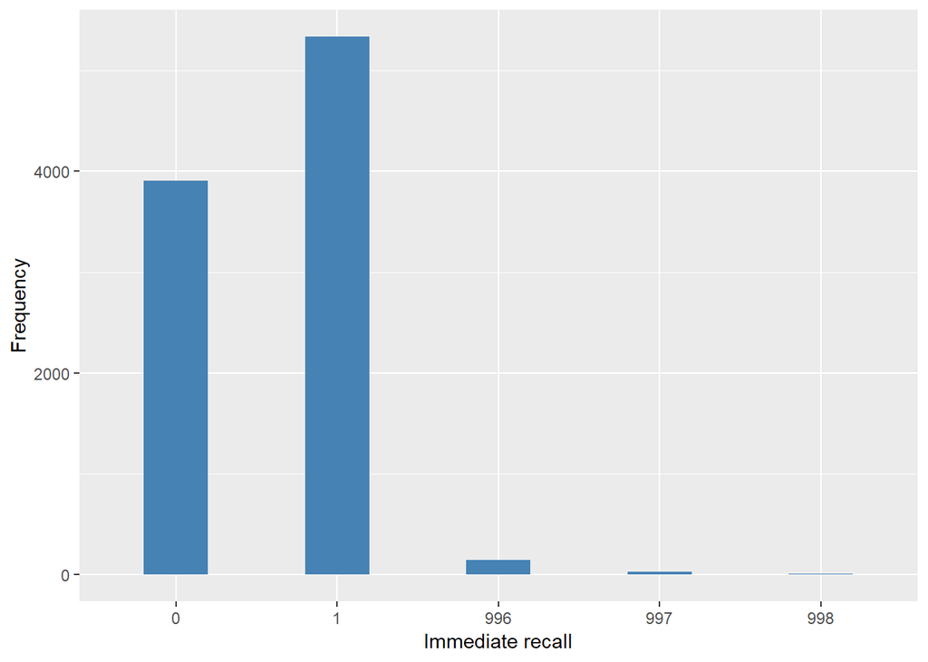

#### 2.1.2.4 Validation

Continuous vs Dichotomous

|  | 0:5->0 | 6:10->1 | -1->996 | -9->997 | -8->998 |
| --- | --- | --- | --- | --- | --- |
| continuous | 3905 | 5334 | 148 | 32 | 13 |
| dichotomous | 3905 | 5334 | 148 | 32 | 13 |

### 2.1.3 Wave 3

#### 2.1.3.1 Study-specific variable description

| **Name** | `cflisen` |
| --- | --- |
| **Label** | `Number of words recalled immediately` |
| **Table name** | `wave_3_elsa_data_v4` |
| **Categories** | `Continuous Variable 0-10` |
| **Missings** | `-9 = Refusal` `-1 = Not applicable` |
| **Description** |  |

Immediate recall continuous

| Sample size | Missing values |
| --- | --- |
| 9771 | 286 |

Values

|  | No-missings | -9 | -1 | NA |
| --- | --- | --- | --- | --- |
| Frequency | 9485.00 | 15.00 | 271.00 | 0 |
| Percentage | 97.07 | 0.15 | 2.77 | 0 |

Summary

| Min. | 1st Qu. | Median | Mean | 3rd Qu. | Max. |
| --- | --- | --- | --- | --- | --- |
| 0 | 5 | 6 | 5.784 | 7 | 10 |

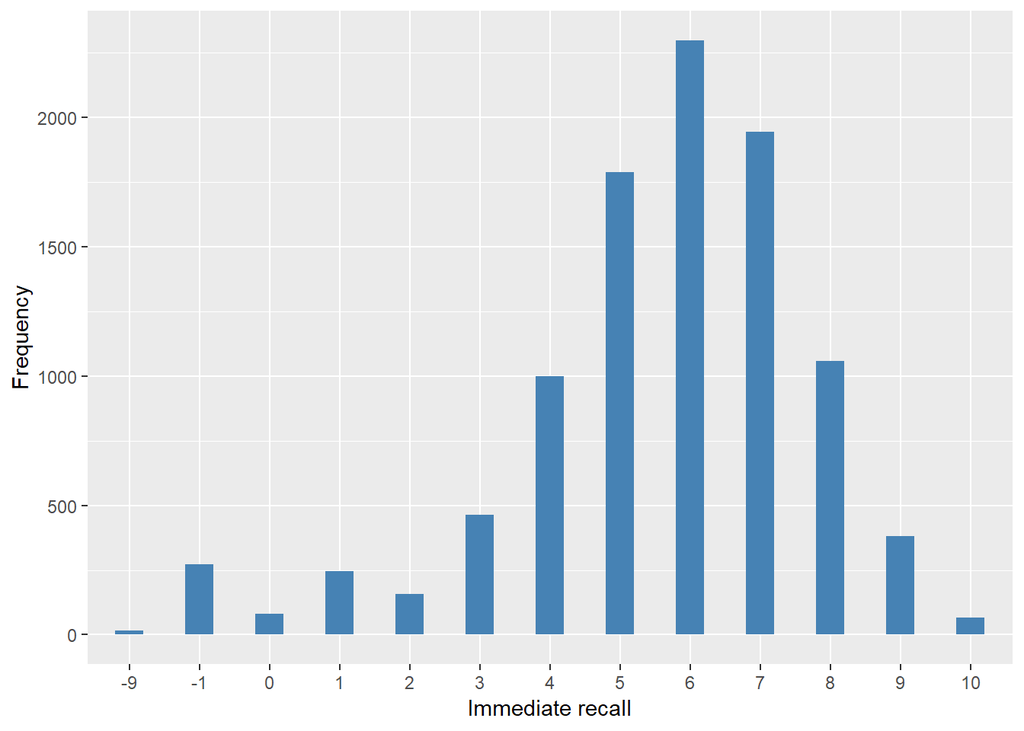

#### 2.1.3.2 Harmonisation algorithm

To compute the harmonize variable `cog_imm_c` from the study-specific variable the missing values have to be recoded as follows:

- `-9 Refusal into 997`
- `-1 Not applicable into 996`
- `NA into 999`

To compute the harmonized variable `cog_imm` from `cog_imm_c` it has to be recoded as follows:

- `cog_imm_c <=25% into 0`
- `cog_imm_c >25% into 1`

**R script**

```r
## cog_imm_c
ELSA_ds_w3 <- tibble(id = ELSA_w3_cog_imm$id)
ELSA_ds_w3$cog_imm_c <- car::recode(ELSA_w3_cog_imm$cflisen, "-9 = 997; -1 = 996")


## cog_imm
Q <- quantile(car::recode(ELSA_ds_w3$cog_imm_c, "999=NA;997=NA;996=NA"), probs = 1/4,
    na.rm = TRUE, names = FALSE)

ELSA_ds_w3$cog_imm <- car::recode(ELSA_ds_w3[[2]], "0:Q=0; (Q+1):10=1")
```

#### 2.1.3.3 Statistical description of the new harmonised variable

Immediate recall of common nouns from a list. The total number of words correctly immediately recalled during a test of verbal memory

| Sample size | Missing values |
| --- | --- |
| 9771 | 286 |

Values

|  | No-missings | 991 | 992 | 993 | 994 | 995 | 996 | 997 | 998 | 999 | NA |
| --- | --- | --- | --- | --- | --- | --- | --- | --- | --- | --- | --- |
| Frequency | 9485.00 | 0 | 0 | 0 | 0 | 0 | 271.00 | 15.00 | 0 | 0 | 0 |
| Percentage | 97.07 | 0 | 0 | 0 | 0 | 0 | 2.77 | 0.15 | 0 | 0 | 0 |

Summary

| Min. | 1st Qu. | Median | Mean | 3rd Qu. | Max. |
| --- | --- | --- | --- | --- | --- |
| 0 | 5 | 6 | 5.784 | 7 | 10 |

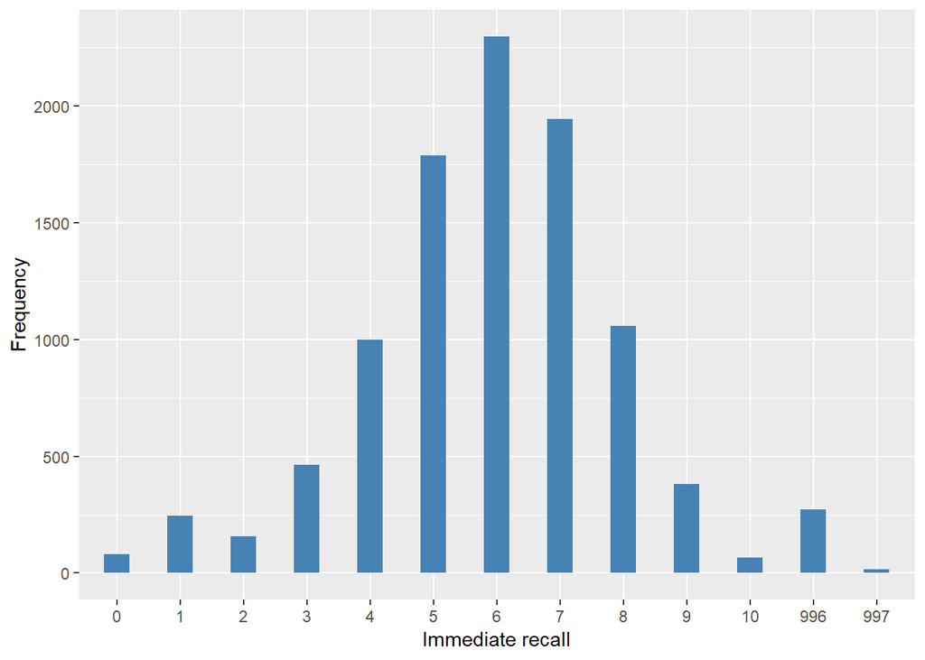

Immediate recall of common nouns from a list. Variable dichotomised by first quartil with value 0 and higher with value 1

| Sample size | Missing values |
| --- | --- |
| 9771 | 286 |

Category

|  | 0 | 1 |
| --- | --- | --- |
| Frequency | 3735.00 | 5750.00 |
| Percentage | 38.23 | 58.85 |

Type of missing

|  | 991 | 992 | 993 | 994 | 995 | 996 | 997 | 998 | 999 | NA |
| --- | --- | --- | --- | --- | --- | --- | --- | --- | --- | --- |
| Frequency | 0 | 0 | 0 | 0 | 0 | 271.00 | 15.00 | 0 | 0 | 0 |
| Percentage | 0 | 0 | 0 | 0 | 0 | 2.77 | 0.15 | 0 | 0 | 0 |

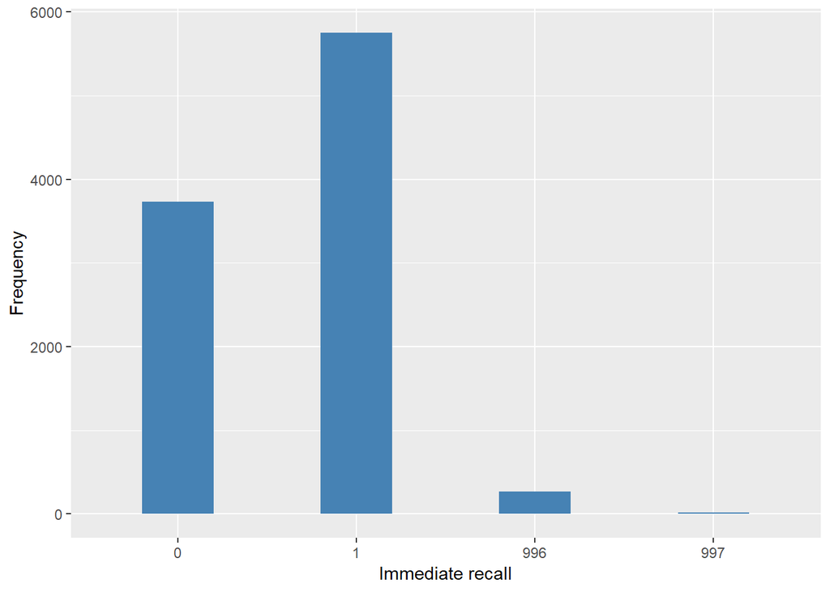

#### 2.1.3.4 Validation

Continuous vs Dichotomous

[output not shown]

### 2.1.4 Wave 4

#### 2.1.4.1 Study-specific variable description

| **Name** | `cflisen` |
| --- | --- |
| **Label** | `Number of words recalled immediately` |
| **Table name** | `wave_4_elsa_data_v3` |
| **Categories** | `Continuous Variable 0-10` |
| **Missings** | `-9 = Refusal` `-1 = Not applicable` |
| **Description** |  |

Immediate recall continuous

| Sample size | Missing values |
| --- | --- |
| 11050 | 506 |

Values

|  | No-missings | -9 | -1 | NA |
| --- | --- | --- | --- | --- |
| Frequency | 10544.00 | 60.00 | 446.00 | 0 |
| Percentage | 95.42 | 0.54 | 4.04 | 0 |

Summary

| Min. | 1st Qu. | Median | Mean | 3rd Qu. | Max. |
| --- | --- | --- | --- | --- | --- |
| 0 | 5 | 6 | 5.836 | 7 | 10 |

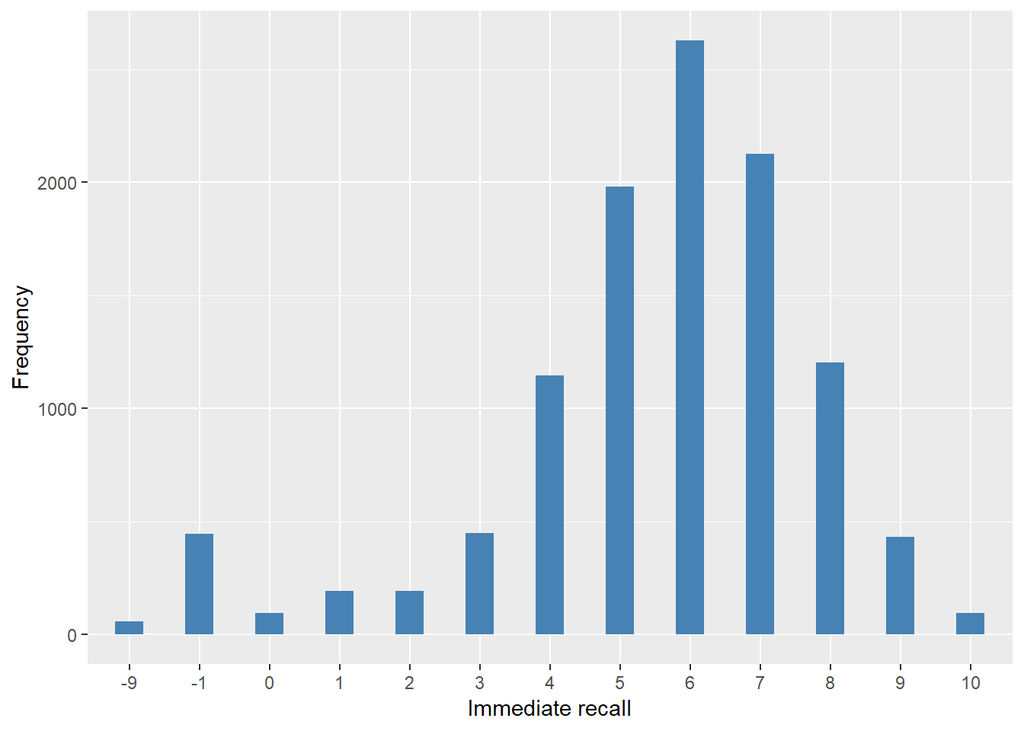

#### 2.1.4.2 Harmonisation algorithm

To compute the harmonize variable `cog_imm_c` from the study-specific variable the missing values have to be recoded as follows:

- `-9 Refusal into 997`
- `-1 Not applicable into 996`
- `NA into 999`

To compute the harmonized variable `cog_imm` from `cog_imm_c` it has to be recoded as follows:

- `cog_imm_c <=25% into 0`
- `cog_imm_c >25% into 1`

**R script**

```r
## cog_imm_c
ELSA_ds_w4 <- tibble(id = ELSA_w4_cog_imm$id)
ELSA_ds_w4$cog_imm_c <- car::recode(ELSA_w4_cog_imm$cflisen, "-9 = 997;-1 = 996")


## cog_imm
Q <- quantile(car::recode(ELSA_ds_w4$cog_imm_c, "999=NA;997=NA;996=NA"), probs = 1/4,
    na.rm = TRUE, names = FALSE)

ELSA_ds_w4$cog_imm <- car::recode(ELSA_ds_w4[[2]], "0:Q=0; (Q+1):10=1")
```

#### 2.1.4.3 Statistical description of the new harmonised variable

Immediate recall of common nouns from a list. The total number of words correctly immediately recalled during a test of verbal memory

| Sample size | Missing values |
| --- | --- |
| 11050 | 506 |

Values

|  | No-missings | 991 | 992 | 993 | 994 | 995 | 996 | 997 | 998 | 999 | NA |
| --- | --- | --- | --- | --- | --- | --- | --- | --- | --- | --- | --- |
| Frequency | 10544.00 | 0 | 0 | 0 | 0 | 0 | 446.00 | 60.00 | 0 | 0 | 0 |
| Percentage | 95.42 | 0 | 0 | 0 | 0 | 0 | 4.04 | 0.54 | 0 | 0 | 0 |

Summary

| Min. | 1st Qu. | Median | Mean | 3rd Qu. | Max. |
| --- | --- | --- | --- | --- | --- |
| 0 | 5 | 6 | 5.836 | 7 | 10 |

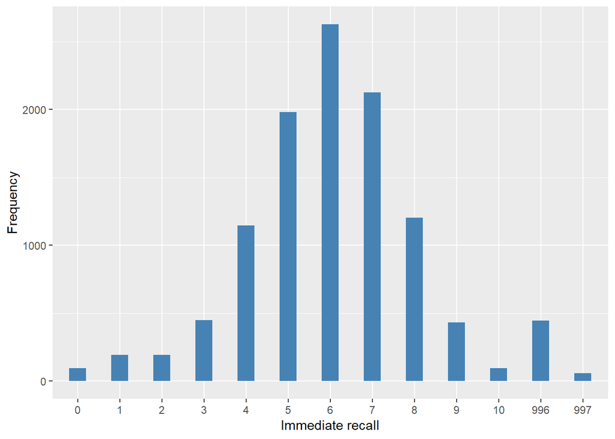

Immediate recall of common nouns from a list. Variable dichotomised by first quartil with value 0 and higher with value 1

| Sample size | Missing values |
| --- | --- |
| 11050 | 506 |

Category

|  | 0 | 1 |
| --- | --- | --- |
| Frequency | 4060.00 | 6484.00 |
| Percentage | 36.74 | 58.68 |

Type of missing

|  | 991 | 992 | 993 | 994 | 995 | 996 | 997 | 998 | 999 | NA |
| --- | --- | --- | --- | --- | --- | --- | --- | --- | --- | --- |
| Frequency | 0 | 0 | 0 | 0 | 0 | 446.00 | 60.00 | 0 | 0 | 0 |
| Percentage | 0 | 0 | 0 | 0 | 0 | 4.04 | 0.54 | 0 | 0 | 0 |

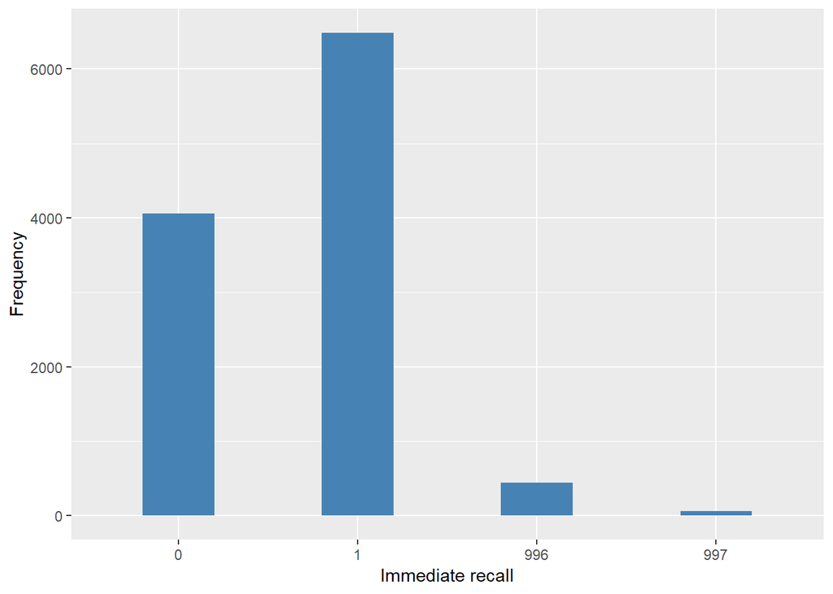

#### 2.1.4.4 Validation

Continuous vs Dichotomous

|  | 0:5->0 | 6:10->1 | -1->996 | -9->997 |
| --- | --- | --- | --- | --- |
| continuous | 4060 | 6484 | 446 | 60 |
| dichotomous | 4060 | 6484 | 446 | 60 |

### 2.1.5 Wave 5

#### 2.1.5.1 Study-specific variable description

| **Name** | `cflisen` |
| --- | --- |
| **Label** | `Number of words recalled immediately` |
| **Table name** | `wave_5_elsa_data_v4` |
| **Categories** | `Continuous Variable 0-10` |
| **Missings** | `-9 = Refusal` `-1 = Not applicable` |
| **Description** |  |

Immediate recall continuous

| Sample size | Missing values |
| --- | --- |
| 10274 | 584 |

Values

|  | No-missings | -9 | -1 | NA |
| --- | --- | --- | --- | --- |
| Frequency | 9690.00 | 47.00 | 537.00 | 0 |
| Percentage | 94.32 | 0.46 | 5.23 | 0 |

Summary

| Min. | 1st Qu. | Median | Mean | 3rd Qu. | Max. |
| --- | --- | --- | --- | --- | --- |
| 0 | 5 | 6 | 5.848 | 7 | 10 |

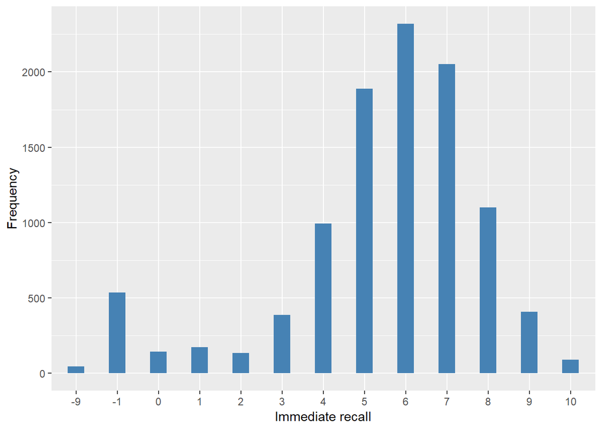

#### 2.1.5.2 Harmonisation algorithm

To compute the harmonize variable `cog_imm_c` from the study-specific variable the missing values have to be recoded as follows:

- `-9 Refusal into 997`
- `-1 Not applicable into 996`
- `NA into 999`

To compute the harmonized variable `cog_imm` from `cog_imm_c` it has to be recoded as follows:

- `cog_imm_c <=25% into 0`
- `cog_imm_c >25% into 1`

**R script**

```r
## cog_imm_c
ELSA_ds_w5 <- tibble(id = ELSA_w5_cog_imm$id)
ELSA_ds_w5$cog_imm_c <- car::recode(ELSA_w5_cog_imm$cflisen, "-9 = 997; -1 = 996")


## cog_imm
Q <- quantile(car::recode(ELSA_ds_w5$cog_imm_c, "999=NA;997=NA;996=NA"), probs = 1/4,
    na.rm = TRUE, names = FALSE)

ELSA_ds_w5$cog_imm <- car::recode(ELSA_ds_w5[[2]], "0:Q=0; (Q+1):10=1")
```

#### 2.1.5.3 Statistical description of the new harmonised variable

Immediate recall of common nouns from a list. The total number of words correctly immediately recalled during a test of verbal memory

| Sample size | Missing values |
| --- | --- |
| 10274 | 584 |

Values

|  | No-missings | 991 | 992 | 993 | 994 | 995 | 996 | 997 | 998 | 999 | NA |
| --- | --- | --- | --- | --- | --- | --- | --- | --- | --- | --- | --- |
| Frequency | 9690.00 | 0 | 0 | 0 | 0 | 0 | 537.00 | 47.00 | 0 | 0 | 0 |
| Percentage | 94.32 | 0 | 0 | 0 | 0 | 0 | 5.23 | 0.46 | 0 | 0 | 0 |

Summary

| Min. | 1st Qu. | Median | Mean | 3rd Qu. | Max. |
| --- | --- | --- | --- | --- | --- |
| 0 | 5 | 6 | 5.848 | 7 | 10 |

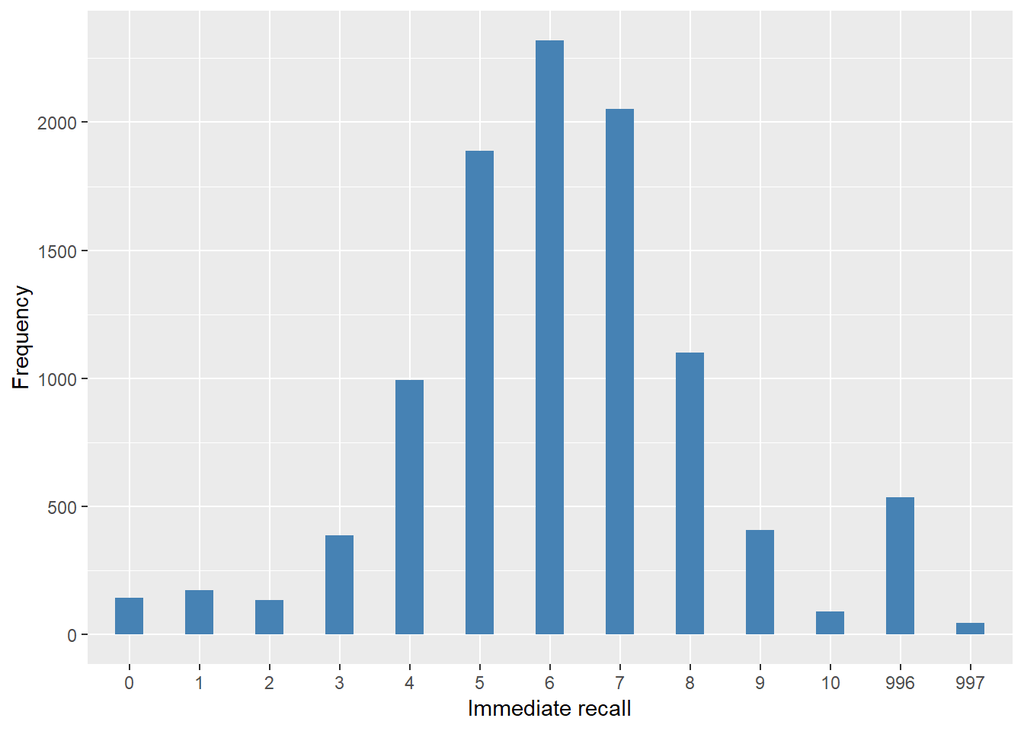

Immediate recall of common nouns from a list. Variable dichotomised by first quartil with value 0 and higher with value 1

| Sample size | Missing values |
| --- | --- |
| 10274 | 584 |

Category

|  | 0 | 1 |
| --- | --- | --- |
| Frequency | 3721.00 | 5969.0 |
| Percentage | 36.22 | 58.1 |

Type of missing

|  | 991 | 992 | 993 | 994 | 995 | 996 | 997 | 998 | 999 | NA |
| --- | --- | --- | --- | --- | --- | --- | --- | --- | --- | --- |
| Frequency | 0 | 0 | 0 | 0 | 0 | 537.00 | 47.00 | 0 | 0 | 0 |
| Percentage | 0 | 0 | 0 | 0 | 0 | 5.23 | 0.46 | 0 | 0 | 0 |

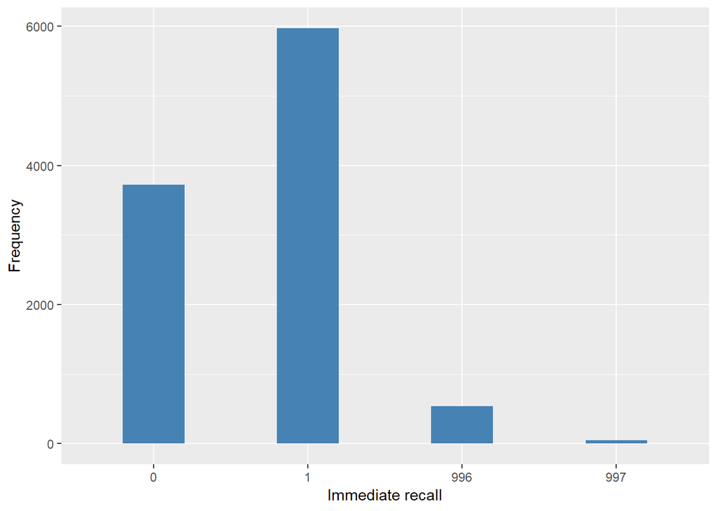

#### 2.1.5.4 Validation

Continuous vs Dichotomous

|  | 0:5->0 | 6:10->1 | -1->996 | -9->997 |
| --- | --- | --- | --- | --- |
| continuous | 3721 | 5969 | 537 | 47 |
| dichotomous | 3721 | 5969 | 537 | 47 |

### 2.1.6 Wave 6

#### 2.1.6.1 Study-specific variable description

| **Name** | `CfLisEn` |
| --- | --- |
| **Label** | `Number of words recalled immediately` |
| **Table name** | `wave_6_elsa_data_v2` |
| **Categories** | `Continuous Variable 0-10` |
| **Missings** | `-9 = Refusal` `-1 = Not applicable` |
| **Description** |  |

Immediate recall continuous

| Sample size | Missing values |
| --- | --- |
| 10601 | 629 |

Values

|  | No-missings | -9 | -1 | NA |
| --- | --- | --- | --- | --- |
| Frequency | 9972.00 | 4.00 | 625.0 | 0 |
| Percentage | 94.07 | 0.04 | 5.9 | 0 |

Summary

| Min. | 1st Qu. | Median | Mean | 3rd Qu. | Max. |
| --- | --- | --- | --- | --- | --- |
| 0 | 5 | 6 | 5.917 | 7 | 10 |

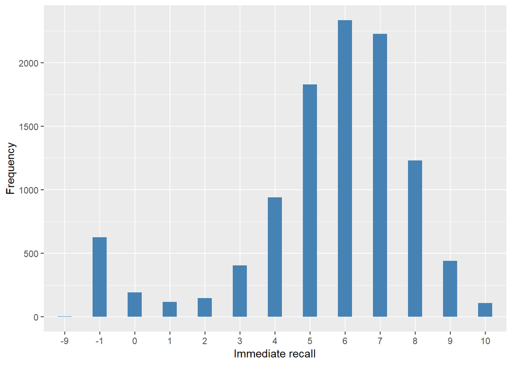

#### 2.1.6.2 Harmonisation algorithm

To compute the harmonize variable `cog_imm_c` from the study-specific variable the missing values have to be recoded as follows:

- `-9 Refusal into 997`
- `-1 Not applicable into 996`
- `NA into 999`

To compute the harmonized variable `cog_imm` from `cog_imm_c` it has to be recoded as follows:

- `cog_imm_c <=25% into 0`
- `cog_imm_c >25% into 1`

**R script**

```r
## cog_imm_c
ELSA_ds_w6 <- tibble(id = ELSA_w6_cog_imm$id)
ELSA_ds_w6$cog_imm_c <- car::recode(ELSA_w6_cog_imm$CfLisEn, "-9 = 997; -1 = 996")


## cog_imm
Q <- quantile(car::recode(ELSA_ds_w6$cog_imm_c, "999=NA;997=NA;996=NA"), probs = 1/4,
    na.rm = TRUE, names = FALSE)

ELSA_ds_w6$cog_imm <- car::recode(ELSA_ds_w6[[2]], "0:Q=0; (Q+1):10=1")
```

#### 2.1.6.3 Statistical description of the new harmonised variable

Immediate recall of common nouns from a list. The total number of words correctly immediately recalled during a test of verbal memory

| Sample size | Missing values |
| --- | --- |
| 10601 | 629 |

Values

|  | No-missings | 991 | 992 | 993 | 994 | 995 | 996 | 997 | 998 | 999 | NA |
| --- | --- | --- | --- | --- | --- | --- | --- | --- | --- | --- | --- |
| Frequency | 9972.00 | 0 | 0 | 0 | 0 | 0 | 625.0 | 4.00 | 0 | 0 | 0 |
| Percentage | 94.07 | 0 | 0 | 0 | 0 | 0 | 5.9 | 0.04 | 0 | 0 | 0 |

Summary

| Min. | 1st Qu. | Median | Mean | 3rd Qu. | Max. |
| --- | --- | --- | --- | --- | --- |
| 0 | 5 | 6 | 5.917 | 7 | 10 |

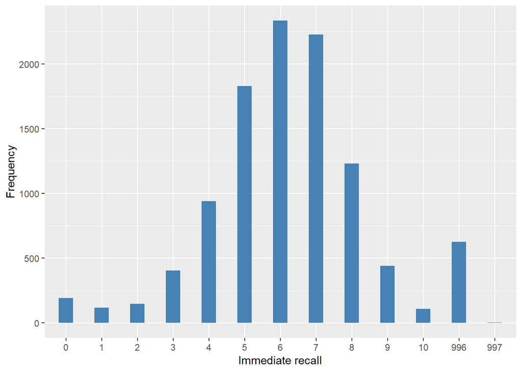

Immediate recall of common nouns from a list. Variable dichotomised by first quartil with value 0 and higher with value 1

| Sample size | Missing values |
| --- | --- |
| 10601 | 629 |

Category

|  | 0 | 1 |
| --- | --- | --- |
| Frequency | 3633.00 | 6339.0 |
| Percentage | 34.27 | 59.8 |

Type of missing

|  | 991 | 992 | 993 | 994 | 995 | 996 | 997 | 998 | 999 | NA |
| --- | --- | --- | --- | --- | --- | --- | --- | --- | --- | --- |
| Frequency | 0 | 0 | 0 | 0 | 0 | 625.0 | 4.00 | 0 | 0 | 0 |
| Percentage | 0 | 0 | 0 | 0 | 0 | 5.9 | 0.04 | 0 | 0 | 0 |

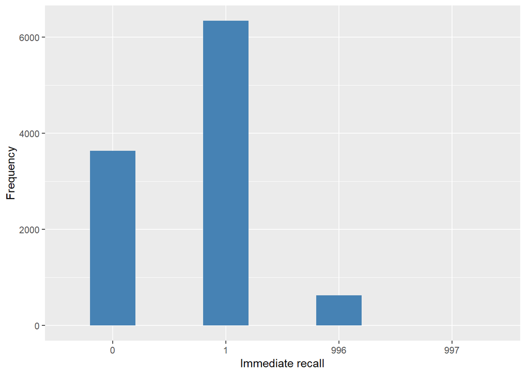

#### 2.1.6.4 Validation

Continuous vs Dichotomous

|  | 0:5->0 | 6:10->1 | -1->996 | -9->997 |
| --- | --- | --- | --- | --- |
| continuous | 3633 | 6339 | 625 | 4 |
| dichotomous | 3633 | 6339 | 625 | 4 |

### 2.1.7 Wave 7

#### 2.1.7.1 Study-specific variable description

| **Name** | `CfLisEn` |
| --- | --- |
| **Label** | `Number of words recalled immediately` |
| **Table name** | `wave_7_elsa_data` |
| **Categories** | `Continuous Variable 0-10` |
| **Missings** | `-9 = Refusal` `-1 = Not applicable` |
| **Description** |  |

Immediate recall continuous

[output not shown]

Values

[output not shown]

Summary

[output not shown]

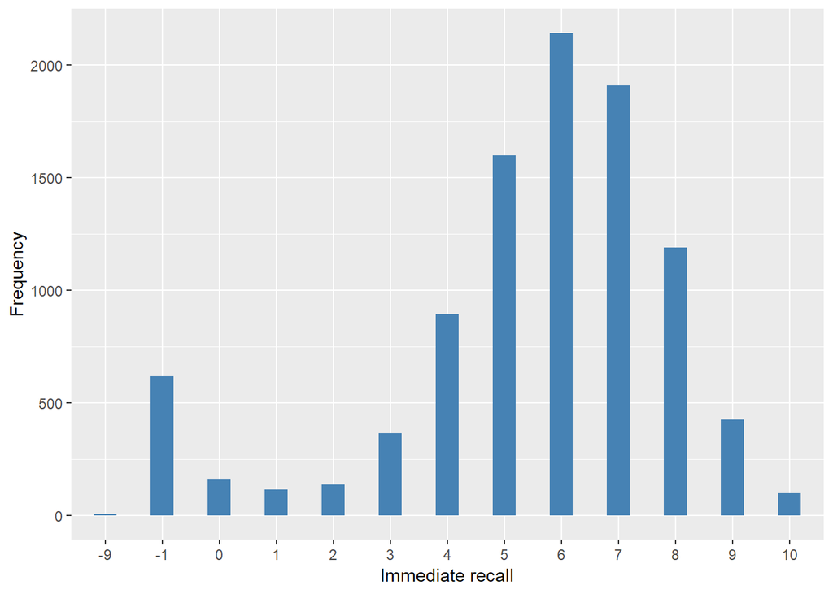

#### 2.1.7.2 Harmonisation algorithm

To compute the harmonize variable `cog_imm_c` from the study-specific variable the missing values have to be recoded as follows:

- `-9 Refusal into 997`
- `-1 Not applicable into 996`
- `NA into 999`

To compute the harmonized variable `cog_imm` from `cog_imm_c` it has to be recoded as follows:

- `cog_imm_c <=25% into 0`
- `cog_imm_c >25% into 1`

**R script**

```r
## cog_imm_c
ELSA_ds_w7 <- tibble(id = ELSA_w7_cog_imm$id)
ELSA_ds_w7$cog_imm_c <- car::recode(ELSA_w7_cog_imm$CfLisEn, "-9 = 997;-1 = 996")


## cog_imm
Q <- quantile(car::recode(ELSA_ds_w7$cog_imm_c, "999=NA;997=NA;996=NA"), probs = 1/4,
    na.rm = TRUE, names = FALSE)

ELSA_ds_w7$cog_imm <- car::recode(ELSA_ds_w7[[2]], "0:Q=0; (Q+1):10=1")
```

#### 2.1.7.3 Statistical description of the new harmonised variable

Immediate recall of common nouns from a list. The total number of words correctly immediately recalled during a test of verbal memory

| Sample size | Missing values |
| --- | --- |
| 9666 | 626 |

Values

|  | No-missings | 991 | 992 | 993 | 994 | 995 | 996 | 997 | 998 | 999 | NA |
| --- | --- | --- | --- | --- | --- | --- | --- | --- | --- | --- | --- |
| Frequency | 9040.00 | 0 | 0 | 0 | 0 | 0 | 620.00 | 6.00 | 0 | 0 | 0 |
| Percentage | 93.52 | 0 | 0 | 0 | 0 | 0 | 6.41 | 0.06 | 0 | 0 | 0 |

Summary

| Min. | 1st Qu. | Median | Mean | 3rd Qu. | Max. |
| --- | --- | --- | --- | --- | --- |
| 0 | 5 | 6 | 5.932 | 7 | 10 |

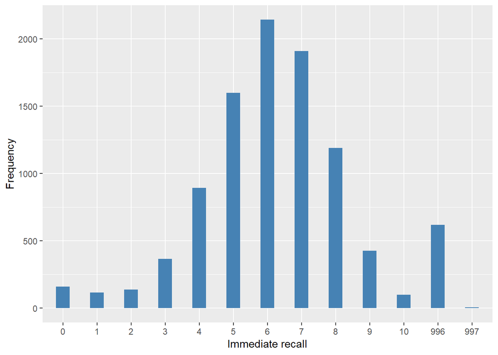

Immediate recall of common nouns from a list. Variable dichotomised by first quartil with value 0 and higher with value 1

| Sample size | Missing values |
| --- | --- |
| 9666 | 626 |

Category

|  | 0 | 1 |
| --- | --- | --- |
| Frequency | 3273.00 | 5767.00 |
| Percentage | 33.86 | 59.66 |

Type of missing

|  | 991 | 992 | 993 | 994 | 995 | 996 | 997 | 998 | 999 | NA |
| --- | --- | --- | --- | --- | --- | --- | --- | --- | --- | --- |
| Frequency | 0 | 0 | 0 | 0 | 0 | 620.00 | 6.00 | 0 | 0 | 0 |
| Percentage | 0 | 0 | 0 | 0 | 0 | 6.41 | 0.06 | 0 | 0 | 0 |

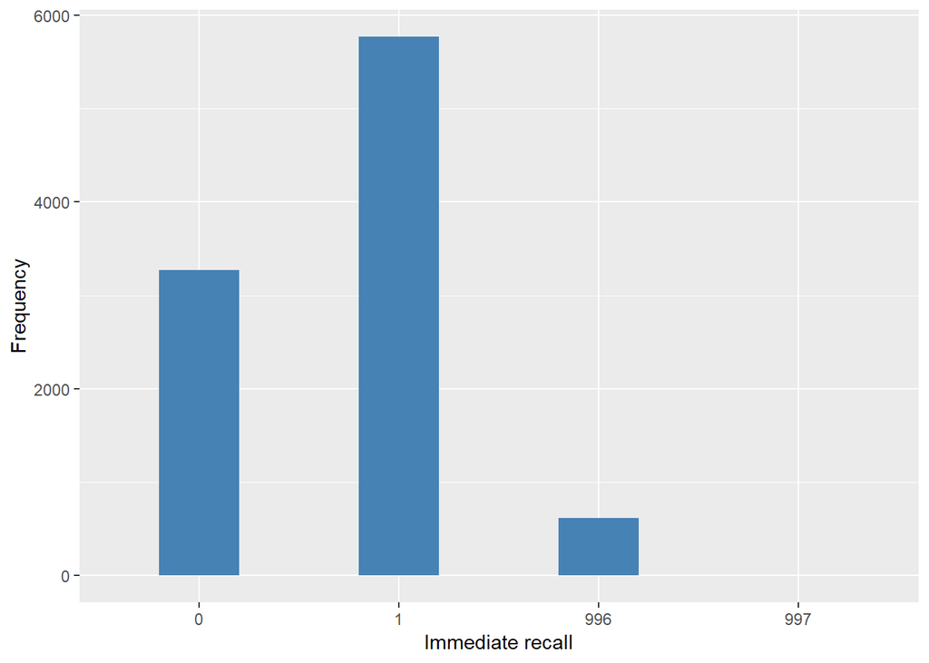

#### 2.1.7.4 Validation

Continuous vs Dichotomous

[output not shown]

## 2.2 Descriptive statistics of the harmonised variable `cog_imm` accross populations and waves

Two tables are generated:

1. Percentages of categories in each harmonised variable.
2. Frequencies and percentages of individuals with different trajectories. To avoid too large table, only trajectories with percentages larger than 0.3 are shown.

Immediate recall of common nouns from a list. Variable dichotomised by first quartil with value 0 and higher with value 1

| val | label | W1 | W2 | W3 | W4 | W5 | W6 | W7 |
| --- | --- | --- | --- | --- | --- | --- | --- | --- |
| 0 | <=25% | 25.25 | 41.4 | 38.23 | 36.74 | 36.22 | 34.27 | 33.86 |
| 1 | >25% | 71.58 | 56.55 | 58.85 | 58.68 | 58.1 | 59.8 | 59.66 |
| 991 | CAPI interviewer error | 0 | 0 | 0 | 0 | 0 | 0 | 0 |
| 992 | Impute | 0 | 0 | 0 | 0 | 0 | 0 | 0 |
| 993 | Disable to measure | 0 | 0 | 0 | 0 | 0 | 0 | 0 |
| 994 | Not attempt not done | 0 | 0 | 0 | 0 | 0 | 0 | 0 |
| 995 | Does not answer | 0 | 0 | 0 | 0 | 0 | 0 | 0 |
| 996 | Not applicable | 2.41 | 1.57 | 2.77 | 4.04 | 5.23 | 5.9 | 6.41 |
| 997 | Refuse | 0.63 | 0.34 | 0.15 | 0.54 | 0.46 | 0.04 | 0.06 |
| 998 | Do not know | 0.14 | 0.14 | 0 | 0 | 0 | 0 | 0 |
| 999 | Missing | 0 | 0 | 0 | 0 | 0 | 0 | 0 |
| NA | NA | 0 | 0 | 0 | 0 | 0 | 0 | 0 |
| n | sample size | 12099 | 9432 | 9771 | 11050 | 10274 | 10601 | 9666 |

|  | val | frq | raw.prc |
| --- | --- | --- | --- |
| 1 | 0000000 | 145 | 0.78 |
| 3 | 000000NA | 85 | 0.46 |
| 8 | 00000NANA | 77 | 0.42 |
| 19 | 0000NANANA | 130 | 0.70 |
| 50 | 000NANANANA | 252 | 1.36 |
| 111 | 00NANANANANA | 358 | 1.94 |
| 218 | 01NANANANANA | 79 | 0.43 |
| 290 | 0NANANANANANA | 836 | 4.52 |
| 291 | 1000000 | 141 | 0.76 |
| 293 | 100000NA | 57 | 0.31 |
| 312 | 1000NANANA | 106 | 0.57 |
| 348 | 100NANANANA | 198 | 1.07 |
| 379 | 1011111 | 114 | 0.62 |
| 405 | 101NANANANA | 89 | 0.48 |
| 450 | 10NANANANANA | 344 | 1.86 |
| 451 | 1100000 | 73 | 0.39 |
| 483 | 1101111 | 114 | 0.62 |
| 508 | 110NANANANA | 117 | 0.63 |
| 521 | 1110111 | 116 | 0.63 |
| 536 | 1111011 | 134 | 0.72 |
| 541 | 1111100 | 61 | 0.33 |
| 542 | 1111101 | 131 | 0.71 |
| 544 | 1111110 | 167 | 0.90 |
| 545 | 1111111 | 1130 | 6.11 |
| 546 | 111111NA | 110 | 0.59 |
| 549 | 11111NANA | 74 | 0.40 |
| 558 | 1111NANANA | 104 | 0.56 |
| 579 | 111NANANANA | 249 | 1.35 |
| 635 | 11NANANANANA | 517 | 2.80 |
| 761 | 1NANANANANANA | 1231 | 6.66 |
| 898 | NANA0NANANANA | 113 | 0.61 |
| 931 | NANA11111 | 359 | 1.94 |
| 935 | NANA111NANA | 57 | 0.31 |
| 943 | NANA11NANANA | 56 | 0.30 |
| 964 | NANA1NANANANA | 220 | 1.19 |
| 965 | NANANA0000 | 147 | 0.80 |
| 967 | NANANA000NA | 65 | 0.35 |
| 968 | NANANA0010 | 58 | 0.31 |
| 978 | NANANA0111 | 93 | 0.50 |
| 989 | NANANA0NANANA | 167 | 0.90 |
| 990 | NANANA1000 | 57 | 0.31 |
| 994 | NANANA1011 | 106 | 0.57 |
| 1000 | NANANA1101 | 92 | 0.50 |
| 1002 | NANANA1110 | 102 | 0.55 |
| 1003 | NANANA1111 | 592 | 3.20 |
| 1004 | NANANA111NA | 78 | 0.42 |
| 1007 | NANANA11NANA | 82 | 0.44 |
| 1016 | NANANA1NANANA | 191 | 1.03 |
| 1034 | NANANANANA00 | 115 | 0.62 |
| 1035 | NANANANANA01 | 105 | 0.57 |
| 1036 | NANANANANA0NA | 84 | 0.45 |
| 1037 | NANANANANA10 | 109 | 0.59 |
| 1038 | NANANANANA11 | 549 | 2.97 |
| 1039 | NANANANANA1NA | 176 | 0.95 |
| 1040 | NANANANANANA0 | 139 | 0.75 |
| 1041 | NANANANANANA1 | 329 | 1.78 |
| 1042 | NANANANANANANA | 596 | 3.22 |

## 2.3 Summary of descriptive statistics of the harmonised variable `cog_imm_c` accross populations and waves

Immediate recall of common nouns from a list. The total number of words correctly immediately recalled during a test of verbal memory

| cog_imm_c | W1 | W2 | W3 | W4 | W5 | W6 | W7 |
| --- | --- | --- | --- | --- | --- | --- | --- |
| Min. | 0 | 0 | 0 | 0 | 0 | 0 | 0 |
| 1st Qu. | 4 | 5 | 5 | 5 | 5 | 5 | 5 |
| Median | 6 | 6 | 6 | 6 | 6 | 6 | 6 |
| Mean | 5.46 | 5.658 | 5.784 | 5.836 | 5.848 | 5.918 | 5.932 |
| 3rd Qu. | 7 | 7 | 7 | 7 | 7 | 7 | 7 |
| Max. | 10 | 10 | 10 | 10 | 10 | 10 | 10 |
| No-missings | 11715 | 9239 | 9485 | 10544 | 9690 | 9972 | 9040 |
| 991 | 0 | 0 | 0 | 0 | 0 | 0 | 0 |
| 992 | 0 | 0 | 0 | 0 | 0 | 0 | 0 |
| 993 | 0 | 0 | 0 | 0 | 0 | 0 | 0 |
| 994 | 0 | 0 | 0 | 0 | 0 | 0 | 0 |
| 995 | 0 | 0 | 0 | 0 | 0 | 0 | 0 |
| 996 | 291 | 148 | 271 | 446 | 537 | 625 | 620 |
| 997 | 76 | 32 | 15 | 60 | 47 | 4 | 6 |
| 998 | 17 | 13 | 0 | 0 | 0 | 0 | 0 |
| 999 | 0 | 0 | 0 | 0 | 0 | 0 | 0 |
| NA | 0 | 0 | 0 | 0 | 0 | 0 | 0 |
| sample size | 12099 | 9432 | 9771 | 11050 | 10274 | 10601 | 9666 |

# 3 Quality estimation

No comments